# regression_analysis

2022-10-03

## Loading the cleaned data

```r
listings_final <- read_csv("listings_final.csv")
```

## Checking for Noramlity of price (DV)

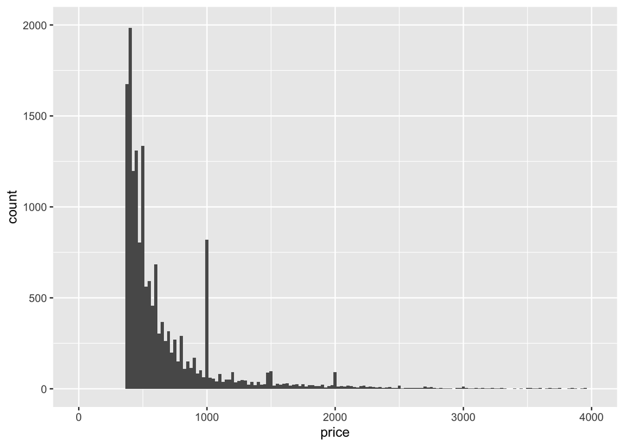

```r
ggplot(listings_final, aes(price))+ geom_histogram(binwidth = 25)+ xlim(0, 4000) + ylim(0, 2000)
```

Since normality does not hold for price we take the log of price.

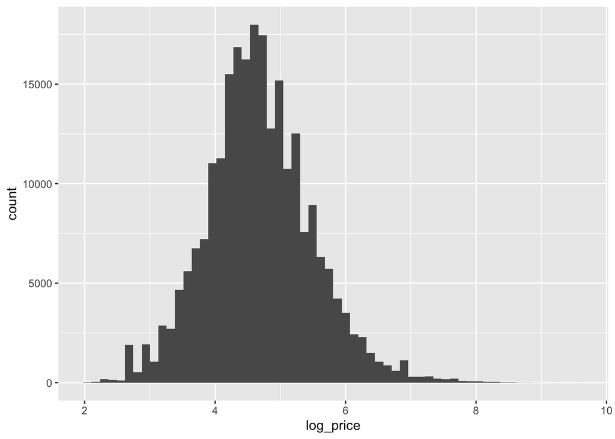

```r
listings_final <- listings_final %>% mutate(log_price=log(price))
ggplot(listings_final, aes(log_price)) + geom_histogram(bins=60)
```

## Multiple linear regression

The multiple linear regression was conducted using the log price as the dependent variable and all the relavant variables as the independent variables.

```r
lm_listings <- lm(log_price ~ city + host_is_superhost + host_identity_verified + property_type + room_type + accommodates + bathrooms_text + bedrooms + beds + minimum_nights + maximum_nights + number_of_reviews + review_scores_rating + review_scores_accuracy + review_scores_cleanliness + review_scores_checkin + review_scores_communication + review_scores_location + review_scores_value + instant_bookable, data = listings_final)
summary(lm_listings)
```

```
##
## Call:
## lm(formula = log_price ~ city + host_is_superhost + host_identity_verified +
##     property_type + room_type + accommodates + bathrooms_text +
##     bedrooms + beds + minimum_nights + maximum_nights + number_of_reviews +
##     review_scores_rating + review_scores_accuracy + review_scores_cleanliness +
##     review_scores_checkin + review_scores_communication + review_scores_location +
##     review_scores_value + instant_bookable, data = listings_final)
##
## Residuals:
##     Min      1Q  Median      3Q     Max
## -7.5893 -0.3161 -0.0214  0.2965  7.7877
##
## Coefficients:
##                                            Estimate Std. Error  t value
## (Intercept)                               4.795e+00  9.137e-03  524.737
## cityAntwerp                              -8.484e-01  1.472e-02  -57.627
## cityBarcelona                            -5.990e-01  8.353e-03  -71.714
## cityBerlin                               -8.427e-01  8.438e-03  -99.869
## cityBordeaux                             -8.515e-01  8.999e-03  -94.631
## cityBrussels                             -7.664e-01  1.033e-02  -74.212
## cityEuskadi                              -5.301e-01  1.007e-02  -52.660
## cityGhent                                -7.439e-01  1.932e-02  -38.498
## cityGirona                               -8.294e-01  8.256e-03 -100.453
## cityLisbon                               -7.484e-01  8.167e-03  -91.631
## cityLyon                                 -7.857e-01  9.207e-03  -85.332
## cityMadrid                               -7.356e-01  8.157e-03  -90.173
## cityMalaga                               -7.557e-01  9.797e-03  -77.133
## cityMallorca                             -5.812e-01  8.468e-03  -68.638
## cityMenorca                              -4.911e-01  1.169e-02  -41.998
## cityMunich                               -4.939e-01  1.103e-02  -44.762
## cityParis                                -4.393e-01  7.580e-03  -57.955
## cityPays Basque                          -7.970e-01  8.767e-03  -90.906
## cityPorto                                -9.740e-01  8.940e-03 -108.946
## cityRotterdam                            -5.378e-01  1.983e-02  -27.123
## citySevilla                              -9.204e-01  1.015e-02  -90.684
## cityThe Hague                            -4.597e-01  1.952e-02  -23.549
## cityValencia                             -8.845e-01  1.003e-02  -88.227
## host_is_superhost                         8.960e-02  3.182e-03   28.163
## host_identity_verified                    3.092e-02  3.164e-03    9.770
```

[output cut: 76 more lines]

```
## review_scores_rating                      < 2e-16 ***
## review_scores_accuracy                   6.85e-12 ***
## review_scores_cleanliness                 < 2e-16 ***
## review_scores_checkin                     < 2e-16 ***
## review_scores_communication               < 2e-16 ***
## review_scores_location                    < 2e-16 ***
## review_scores_value                       < 2e-16 ***
## instant_bookable                          < 2e-16 ***
## ---
## Signif. codes:  0 '***' 0.001 '**' 0.01 '*' 0.05 '.' 0.1 ' ' 1
##
## Residual standard error: 0.5551 on 241050 degrees of freedom
##   (188 observations deleted due to missingness)
## Multiple R-squared:  0.5323, Adjusted R-squared:  0.5322
## F-statistic:  5177 on 53 and 241050 DF,  p-value: < 2.2e-16
```

188 observations were deleted due to missingness.

The R-squared and the adjusted R-squared value is between the 0.5 and 0.7, which is generally considered a moderate effect size. The f statistic is significant, meaning we reject the null hypothesis and accept that the independent variables do help predict the dependent variable.

## Check for assumptions

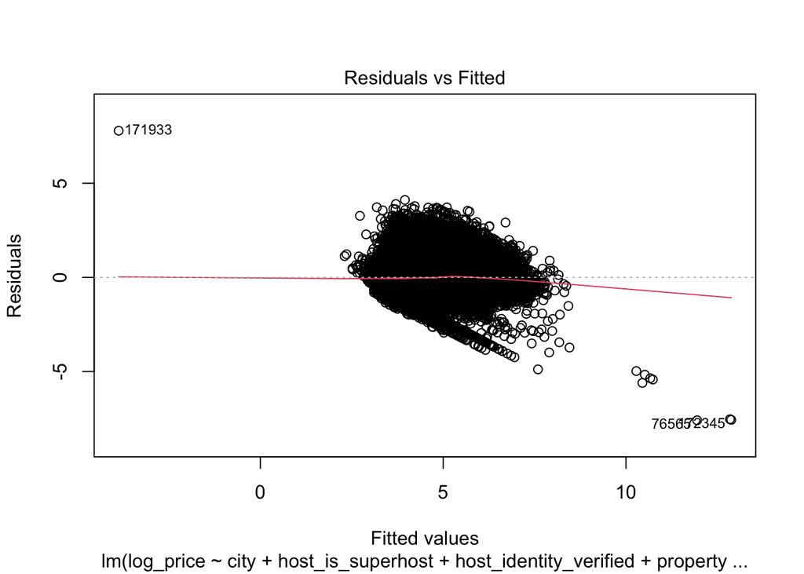

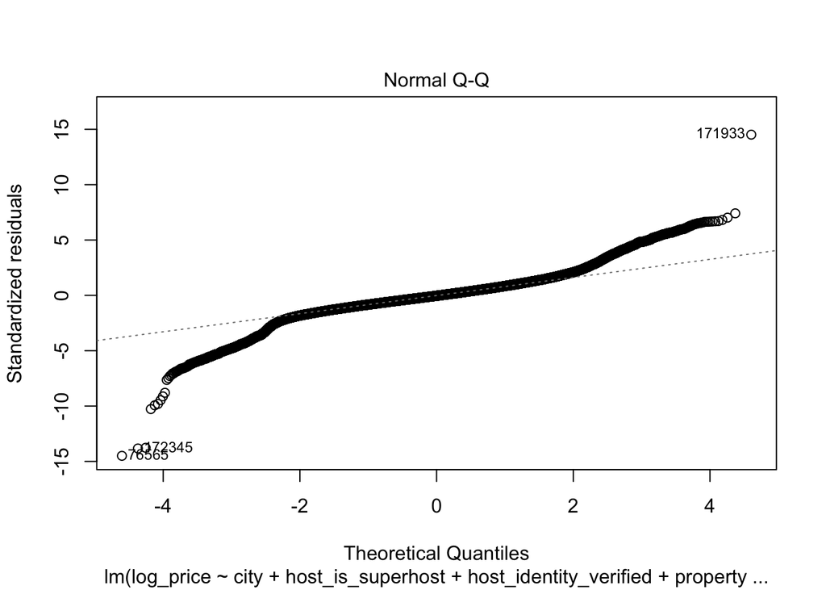

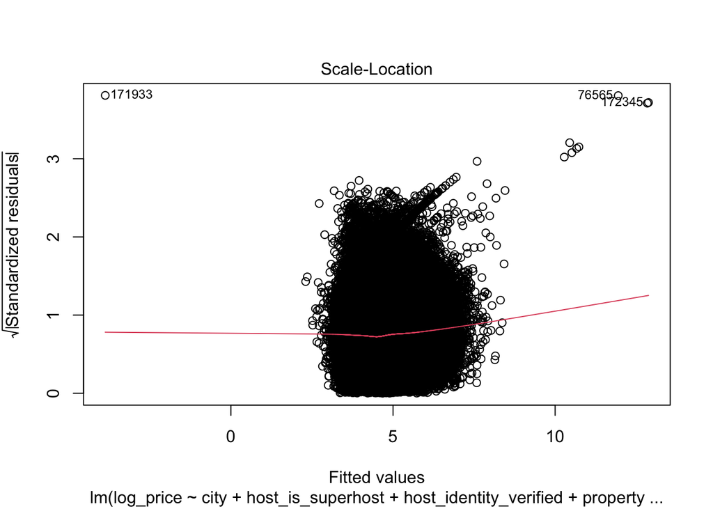

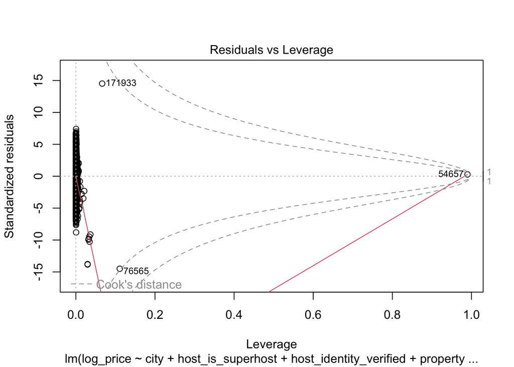

```r
plot(lm_listings)
```

```r
# Create a dataframe with models output
df_lm_listings <- tidy(lm_listings)
```

## Only include the significant variables with a estimate of the cut off > 0.075

```r
df_lm_listings_sig <- df_lm_listings %>% filter(p.value <0.05) %>% filter(abs(estimate) > 0.075)
```

## Make a list with all the variables we want to keep

```r
variable_list_listings <- c('city', 'host_is_superhost', 'property_type', 'room_type', 'accommodates', 'bathrooms_text', 'review_scores_rating', 'review_scores_cleanliness', 'review_scores_checkin', 'review_scores_communication', 'review_scores_location', 'review_scores_value', 'instant_bookable')
```

## Change the variable list so that it can be used in the regression formula

```r
variable_list_listings <- paste0('`',variable_list_listings, '`')
character_variables_listings <- paste0(variable_list_listings, collapse= '+')
```

## Conduct the regression with all the relevant variables

```r
formula_listings <- as.formula(paste0('log(price)~', character_variables_listings))
regression_final <- lm(formula_listings, listings_final)
summary(regression_final)
```

```
##
## Call:
## lm(formula = formula_listings, data = listings_final)
##
## Residuals:
##     Min      1Q  Median      3Q     Max
## -8.4445 -0.3214 -0.0216  0.3015  4.1649
##
## Coefficients:
##                                            Estimate Std. Error  t value
## (Intercept)                               4.8130915  0.0088897  541.423
## cityAntwerp                              -0.8466530  0.0148589  -56.980
## cityBarcelona                            -0.6074647  0.0084342  -72.024
## cityBerlin                               -0.8468736  0.0085100  -99.515
## cityBordeaux                             -0.8728750  0.0090620  -96.322
## cityBrussels                             -0.7632605  0.0104234  -73.226
## cityEuskadi                              -0.5397230  0.0101563  -53.142
## cityGhent                                -0.7500673  0.0195217  -38.422
## cityGirona                               -0.8324302  0.0083045 -100.238
## cityLisbon                               -0.7566903  0.0082436  -91.791
## cityLyon                                 -0.8453221  0.0092234  -91.649
## cityMadrid                               -0.7386584  0.0082346  -89.702
## cityMalaga                               -0.7557778  0.0098844  -76.462
## cityMallorca                             -0.5851796  0.0085254  -68.640
## cityMenorca                              -0.5018640  0.0117807  -42.601
## cityMunich                               -0.4930542  0.0111349  -44.280
## cityParis                                -0.4888936  0.0075818  -64.483
## cityPays Basque                          -0.8019979  0.0088387  -90.737
## cityPorto                                -0.9822249  0.0090119 -108.991
## cityRotterdam                            -0.5439735  0.0200344  -27.152
## citySevilla                              -0.9330265  0.0102455  -91.067
## cityThe Hague                            -0.4597887  0.0197262  -23.309
## cityValencia                             -0.8805034  0.0101269  -86.947
## host_is_superhost                         0.0897073  0.0031078   28.866
## property_typeEntire home                  0.0160950  0.0067679    2.378
## property_typeEntire loft                  0.0807574  0.0098659    8.185
## property_typeEntire rental unit          -0.0146662  0.0051298   -2.859
## property_typeEntire serviced apartment    0.3338834  0.0110279   30.276
## property_typeEntire townhouse             0.0854639  0.0109382    7.813
## property_typeEntire villa                 0.3996804  0.0082093   48.686
```

[output cut: 57 more lines]

```
## bathrooms_text                            < 2e-16 ***
## review_scores_rating                      < 2e-16 ***
## review_scores_cleanliness                 < 2e-16 ***
## review_scores_checkin                     < 2e-16 ***
## review_scores_communication               < 2e-16 ***
## review_scores_location                    < 2e-16 ***
## review_scores_value                       < 2e-16 ***
## instant_bookable                          < 2e-16 ***
## ---
## Signif. codes:  0 '***' 0.001 '**' 0.01 '*' 0.05 '.' 0.1 ' ' 1
##
## Residual standard error: 0.561 on 241113 degrees of freedom
##   (132 observations deleted due to missingness)
## Multiple R-squared:  0.5225, Adjusted R-squared:  0.5224
## F-statistic:  5736 on 46 and 241113 DF,  p-value: < 2.2e-16
```

## Save the output

```r
# In a dataframe
df_regression_final <- tidy(regression_final)

# In a csv file
write.csv(df_regression_final, file = "regression_output_listings.csv", fileEncoding = "UTF-8",row.names=FALSE )

write.csv(variable_list_listings, file = "variable_list_listings.csv", fileEncoding = "UTF-8",row.names=FALSE )
```

## Save the model to make predictions in the shinyapp later on

```r
parsed_regression <- parse_model(regression_final)

write_yaml(parsed_regression, "regression_output_wr.yml")
```